# San Francisco Trees

Tidy Tuesday - 2020-01-28

Omar Lopez Rubio

So this week we have some data on San Francisco trees. This week I’m more interested in plotting some fancy maps than in anything else, so I researched a little bit how to achieve it. I found a package called `leaflet`. It allows you to plot interactive maps using coordinates and also add markers to it. The markers are fully customizable. The only thing I didn’t like is that I didn’t find good docs about it.

```r
library(tidyverse)
knitr::opts_chunk$set(echo = TRUE, fig.align="center")
knitr::opts_chunk$set(fig.width=12, fig.height=8)

sf_trees <- readr::read_csv('https://raw.githubusercontent.com/rfordatascience/tidytuesday/master/data/2020/2020-01-28/sf_trees.csv')

glimpse(sf_trees)
```

```
## Observations: 192,987
## Variables: 12
## $ tree_id      <dbl> 53719, 30313, 30312, 30314, 30315, 30316, 48435, 30319...
## $ legal_status <chr> "Permitted Site", "Permitted Site", "Permitted Site", ...
## $ species      <chr> "Tree(s) ::", "Tree(s) ::", "Tree(s) ::", "Pittosporum...
## $ address      <chr> "2963 Webster St", "501 Arkansas St", "501 Arkansas St...
## $ site_order   <dbl> 1, 3, 2, 1, 5, 6, 4, 2, 1, 3, 1, 3, 1, 2, 4, 1, 1, 1, ...
## $ site_info    <chr> "Sidewalk: Curb side : Cutout", "Sidewalk: Curb side :...
## $ caretaker    <chr> "Private", "Private", "Private", "Private", "Private",...
## $ date         <date> 1955-09-19, 1955-10-20, 1955-10-20, 1955-10-20, 1955-...
## $ dbh          <dbl> NA, NA, NA, 16, NA, NA, NA, NA, NA, NA, 2, NA, NA, NA,...
## $ plot_size    <chr> NA, NA, NA, NA, NA, NA, NA, NA, NA, NA, NA, NA, NA, NA...
## $ latitude     <dbl> 37.79787, 37.75984, 37.75984, 37.75977, 37.79265, 37.7...
## $ longitude    <dbl> -122.4341, -122.3981, -122.3981, -122.3981, -122.4124,...
```

```r
trees <- sf_trees %>%
  mutate_if(is.character, fct_explicit_na)
```

Basic data visualization and exploratory analysis

```r
trees %>%
  count(species) %>%
  arrange(n)
```

```
## # A tibble: 571 x 2
##    species                                             n
##    <fct>                                           <int>
##  1 Acer campestre :: Hedge Maple                       1
##  2 Acer ginnela :: Amur Maple                          1
##  3 Acer paxii :: Evergreen Maple                       1
##  4 Acer platanoides 'Crimson King' :: Norway maple     1
##  5 Acer platanoides :: Norway Maple                    1
##  6 Acer saccharum :: Sugar Maple                       1
##  7 Acer tegmentosum :: Manchurian snakebark maple      1
##  8 Acer x 'Autumn Blaze' :: Hybrid Maple               1
##  9 Aesculus spp :: Horsechestnut                       1
## 10 Alnus rubra :: Red Alder                            1
## # ... with 561 more rows
```

We have a lot of species with less than 100 observations, may be worth to discard those samples. Let’s take a look at `legal_status`

```r
trees %>%
  count(legal_status, sort = TRUE)
```

```
## # A tibble: 10 x 2
##    legal_status                      n
##    <fct>                         <int>
##  1 DPW Maintained               141725
##  2 Permitted Site                39732
##  3 Undocumented                   8106
##  4 Significant Tree               1648
##  5 Planning Code 138.1 required    971
##  6 Property Tree                   316
##  7 Section 143                     230
##  8 Private                         163
##  9 (Missing)                        54
## 10 Landmark tree                    42
```

Here we can see that it happens also with legal_status. I’m going to do some `geom_col()` plots for them and also the other variables, to get a better idea of the dataset.

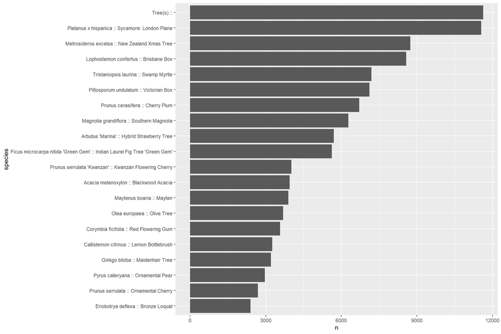

```r
trees %>%
  count(species, sort = TRUE) %>%
  head(20) %>%
  mutate(species = reorder(species, n)) %>%
  ggplot(aes(x = species, y = n)) + geom_col() + coord_flip()
```

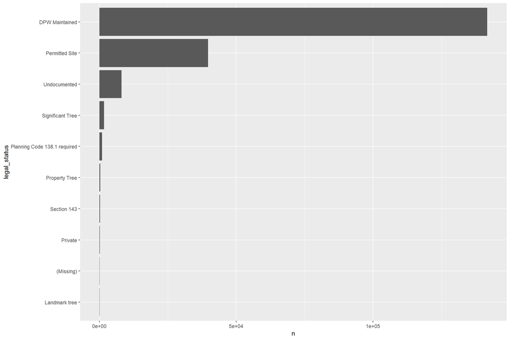

```r
trees %>%
  count(legal_status, sort = TRUE) %>%
  mutate(legal_status = reorder(legal_status, n)) %>%
  ggplot(aes(x = legal_status, y = n)) + geom_col() + coord_flip()
```

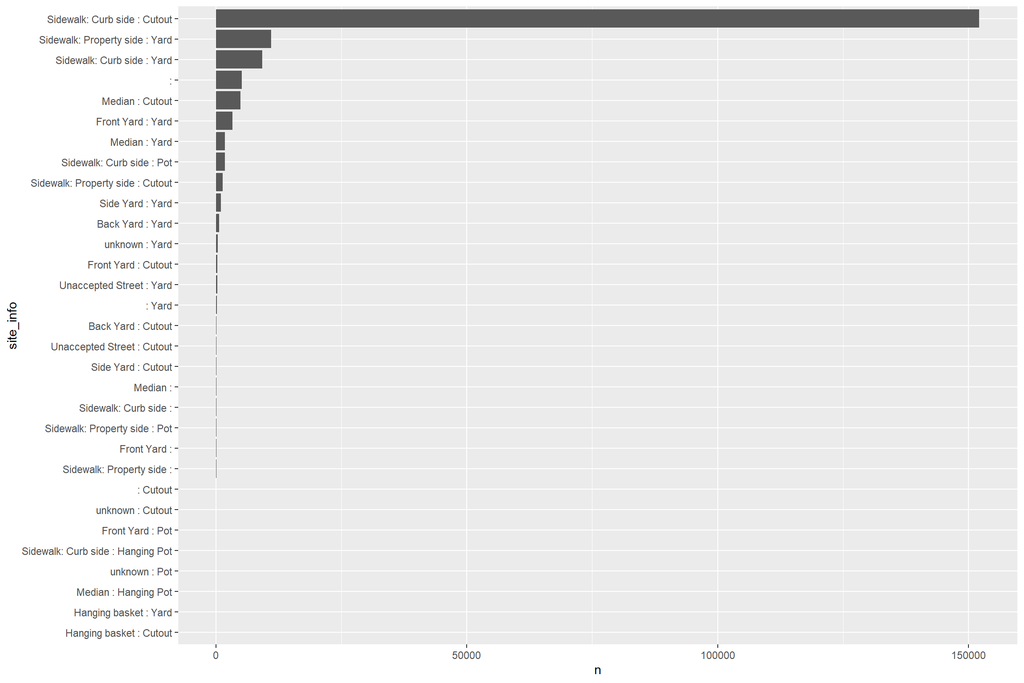

```r
trees %>%
  count(site_info, sort = TRUE) %>%
  mutate(site_info = reorder(site_info, n)) %>%
  ggplot(aes(x = site_info, y = n)) + geom_col() + coord_flip()
```

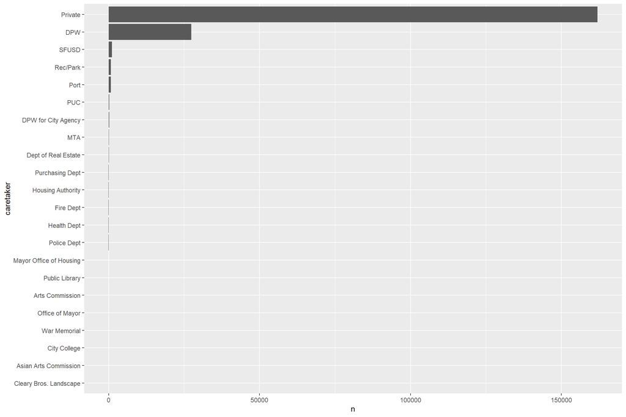

```r
trees %>%
  count(caretaker, sort = TRUE) %>%
  mutate(caretaker = reorder(caretaker, n)) %>%
  ggplot(aes(x = caretaker, y = n)) + geom_col() + coord_flip()
```

So visually we can see that there are some factors that it’s count is really low. For demonstration purposes, I’m going to use `fct_lump` to collapse a little bit the species column.

```r
trees_lump <- trees %>%
  mutate(species = fct_lump_min(species, 100))

trees_lump %>%
  count(species, sort = TRUE)
```

```
## # A tibble: 156 x 2
##    species                                            n
##    <fct>                                          <int>
##  1 Tree(s) ::                                     11629
##  2 Platanus x hispanica :: Sycamore: London Plane 11557
##  3 Metrosideros excelsa :: New Zealand Xmas Tree   8744
##  4 Lophostemon confertus :: Brisbane Box           8581
##  5 Other                                           7842
##  6 Tristaniopsis laurina :: Swamp Myrtle           7197
##  7 Pittosporum undulatum :: Victorian Box          7122
##  8 Prunus cerasifera :: Cherry Plum                6716
##  9 Magnolia grandiflora :: Southern Magnolia       6285
## 10 Arbutus 'Marina' :: Hybrid Strawberry Tree      5702
## # ... with 146 more rows
```

```r
trees_lump %>%
  filter(species == "Other")
```

```
## # A tibble: 7,842 x 12
##    tree_id legal_status species address site_order site_info caretaker
##      <dbl> <fct>        <fct>   <fct>        <dbl> <fct>     <fct>
##  1   30350 DPW Maintai~ Other   440 Ar~          1 Sidewalk~ Private
##  2   53216 DPW Maintai~ Other   828 Ar~          1 Sidewalk~ Private
##  3   53249 DPW Maintai~ Other   348 Te~          1 Sidewalk~ Private
##  4   53309 Permitted S~ Other   1775 1~          1 Sidewalk~ Private
##  5   53302 Permitted S~ Other   38 Lev~          1 Sidewalk~ Private
##  6   53426 Permitted S~ Other   26 Par~          1 Sidewalk~ Private
##  7   53496 DPW Maintai~ Other   37 Coo~          1 Sidewalk~ Private
##  8   53927 Permitted S~ Other   616-61~          1 Sidewalk~ Private
##  9   53947 DPW Maintai~ Other   100 Ga~          1 Sidewalk~ Private
## 10   54018 DPW Maintai~ Other   850 35~          1 Sidewalk~ Private
## # ... with 7,832 more rows, and 5 more variables: date <date>, dbh <dbl>,
## #   plot_size <fct>, latitude <dbl>, longitude <dbl>
```

I’m interested in check wheter the caretaker is private or not, so I’m going to create a new column to check it, and later make a model with `tidymodels`.

```r
trees_proc <- trees_lump %>%
  mutate(isPrivate = case_when(
    as.character(caretaker) == "Private" ~ as.character(caretaker),
            TRUE ~ "Other")) %>%
  filter(longitude > -125) %>%
  select(-caretaker)

trees_proc %>%
  count(isPrivate, sort = TRUE)
```

```
## # A tibble: 2 x 2
##   isPrivate      n
##   <chr>      <int>
## 1 Private   160061
## 2 Other      29964
```

Cool! Let’s end the visualization making a plot with the `lat` and `long` For the sake of complexity and visualization, I’m only going to plot 2000 samples in the interactive plot, and 10000 in the static one.

```r
library(leaflet)

set.seed(555)
pal <- colorFactor(c("green", "navy"), domain = c("Other", "Private"))
trees_proc %>%
  sample_n(2000) %>%
  leaflet() %>%
  addTiles() %>%
  addCircleMarkers(
    radius = 0.5,
    color = ~pal(isPrivate)
  ) %>%
  addLegend("bottomright", pal = pal, values = ~isPrivate,
             title = "Caretaker type")
```

```
## Assuming "longitude" and "latitude" are longitude and latitude, respectively
```

[interactive chart not shown]

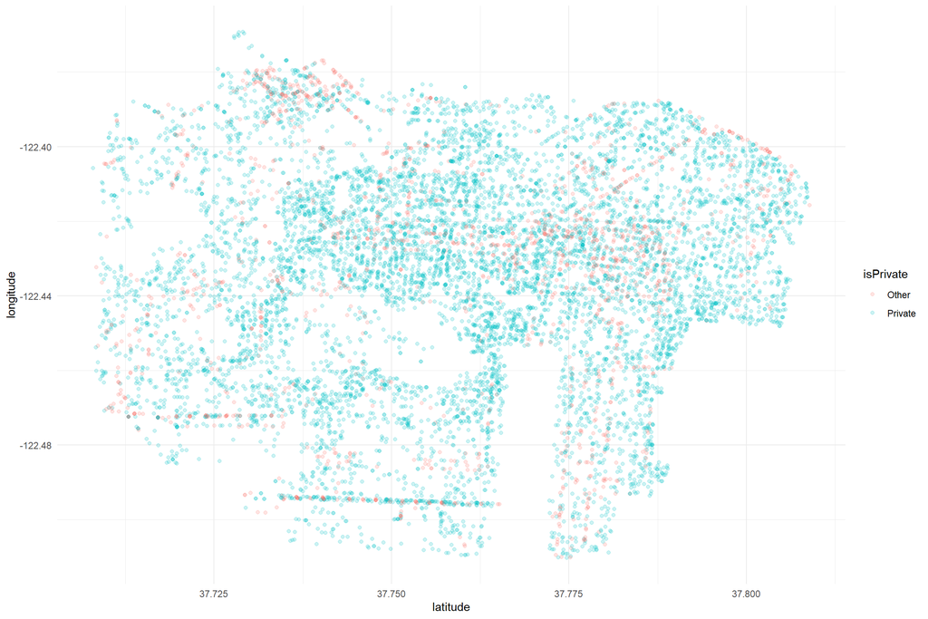

```r
trees_proc %>%
  sample_n(10000) %>%
  ggplot(aes(x=latitude, y = longitude, color = isPrivate)) + geom_point(alpha = 0.2) + theme_minimal()
```

Time to model things! I’m going to downsample `isPrivate`, because we are working with an unbalanced dataset. Also I’m gonna do a little bit more of preprocessing, `recipes` makes it really easy. In Julia Silge’s screencast I saw how she used the `doParallel` library, and after checking the package out I can’t figure why I didn’t use it until now. The training may take a while…

```r
library(tidymodels)
library(lubridate)

trees_proc <- trees_proc %>%
  mutate(site_order = as_factor(site_order)) %>%
  mutate(site_order = fct_explicit_na(site_order, na_level = "-1"))

trees_split <- initial_split(trees_proc)
trees_train <- training(trees_split)
trees_test <- testing(trees_split)

trees_recipe <- trees_train %>%
  recipe(isPrivate ~ .) %>%
  update_role(address, new_role = "loc") %>%
  update_role(tree_id, new_role = "id") %>%
  step_rm(date, plot_size, dbh) %>%
  step_downsample(isPrivate) %>%
  step_dummy(all_predictors(), -all_outcomes(), -all_numeric()) %>%
  prep()


trees_train <- juice(trees_recipe)
trees_testing <- trees_recipe %>%
  bake(trees_test)

library(doParallel)
doParallel::registerDoParallel()
trees_ranger <- rand_forest(trees = 100, mode = "classification") %>%
  set_engine("ranger", importance = "permutation") %>%
  fit(isPrivate ~ ., data = trees_train)

predict(trees_ranger, trees_testing)
```

```
## # A tibble: 47,506 x 1
##    .pred_class
##    <fct>
##  1 Private
##  2 Private
##  3 Private
##  4 Private
##  5 Private
##  6 Private
##  7 Private
##  8 Private
##  9 Private
## 10 Private
## # ... with 47,496 more rows
```

```r
trees_ranger %>%
  predict(trees_testing) %>%
  bind_cols(trees_testing) %>%
  metrics(truth = isPrivate, estimate = .pred_class)
```

```
## # A tibble: 2 x 3
##   .metric  .estimator .estimate
##   <chr>    <chr>          <dbl>
## 1 accuracy binary         0.942
## 2 kap      binary         0.798
```

```r
trees_ranger %>%
  predict(trees_testing) %>%
  count(.pred_class)
```

```
## # A tibble: 2 x 2
##   .pred_class     n
##   <fct>       <int>
## 1 Other        9014
## 2 Private     38492
```